# WriteUp

```python
##imports
from sklearn.tree import DecisionTreeClassifier
import multiclass
import util
import matplotlib.pyplot as plt
from datasets import *
import linear
import runClassifier
import gd
import numpy as np
```

### **WU1**

**(A)** Train depth 3 decision trees on the WineDataSmall task. What words are most indicative of being Sauvignon-Blanc? Which words are most indicative of not being Sauvignon-Blanc? What about Pinot-Noir (label==2)?

##### **OAA**

```python
##OAA Sauvignon-Blanc
h = multiclass.OAA(5, lambda: DecisionTreeClassifier(max_depth=3))
h.train(WineDataSmall.X, WineDataSmall.Y)
util.showTree(h.f[0], WineDataSmall.words)
```

```
training classifier for 0 versus rest
training classifier for 1 versus rest
training classifier for 2 versus rest
training classifier for 3 versus rest
training classifier for 4 versus rest
gives?
-N-> both?
|    -N-> body?
|    |    -N-> class 0	(356 for class 0, 10 for class 1)
|    |    -Y-> class 1	(0 for class 0, 4 for class 1)
|    -Y-> dry?
|    |    -N-> class 1	(1 for class 0, 15 for class 1)
|    |    -Y-> class 0	(2 for class 0, 0 for class 1)
-Y-> two?
|    -N-> 1?
|    |    -N-> class 1	(4 for class 0, 12 for class 1)
|    |    -Y-> class 0	(11 for class 0, 5 for class 1)
|    -Y-> purity?
|    |    -N-> class 1	(0 for class 0, 14 for class 1)
|    |    -Y-> class 0	(1 for class 0, 0 for class 1)
```

```python
##OAA Pinot-Noir
util.showTree(h.f[2], WineDataSmall.words)
```

```
as?
-N-> finish?
|    -N-> medium?
|    |    -N-> class 0	(225 for class 0, 58 for class 1)
|    |    -Y-> class 1	(0 for class 0, 4 for class 1)
|    -Y-> pomegranate?
|    |    -N-> class 1	(0 for class 0, 12 for class 1)
|    |    -Y-> class 0	(1 for class 0, 0 for class 1)
-Y-> along?
|    -N-> vibrant?
|    |    -N-> class 1	(36 for class 0, 68 for class 1)
|    |    -Y-> class 0	(8 for class 0, 0 for class 1)
|    -Y-> sonoma?
|    |    -N-> class 0	(21 for class 0, 0 for class 1)
|    |    -Y-> class 1	(0 for class 0, 2 for class 1)
```

```python
#Sauvignong-Blanc AVA
h = multiclass.AVA(5, lambda: DecisionTreeClassifier(max_depth=3))
h.train(WineDataSmall.X, WineDataSmall.Y)
util.showTree(h.f[1][0], WineDataSmall.words)
print("----------------------------")
util.showTree(h.f[2][0], WineDataSmall.words)
print("----------------------------")
util.showTree(h.f[3][0], WineDataSmall.words)
print("----------------------------")
util.showTree(h.f[4][0], WineDataSmall.words)
```

```
training classifier for 1 versus 0
training classifier for 2 versus 0
training classifier for 2 versus 1
training classifier for 3 versus 0
training classifier for 3 versus 1
training classifier for 3 versus 2
training classifier for 4 versus 0
training classifier for 4 versus 1
training classifier for 4 versus 2
training classifier for 4 versus 3
gives?
-N-> both?
|    -N-> aperitif?
|    |    -N-> class 0	(187 for class 0, 9 for class 1)
|    |    -Y-> class 1	(0 for class 0, 5 for class 1)
|    -Y-> class 1	(0 for class 0, 15 for class 1)
-Y-> class 1	(0 for class 0, 31 for class 1)
----------------------------
boysenberry?
-N-> both?
|    -N-> not?
|    |    -N-> class 0	(141 for class 0, 9 for class 1)
|    |    -Y-> class 1	(0 for class 0, 8 for class 1)
|    -Y-> crimson?
|    |    -N-> class 1	(0 for class 0, 13 for class 1)
|    |    -Y-> class 0	(1 for class 0, 0 for class 1)
-Y-> allspice?
|    -N-> class 1	(0 for class 0, 30 for class 1)
|    -Y-> class 0	(2 for class 0, 0 for class 1)
----------------------------
freshly?
-N-> elegant?
|    -N-> coast?
|    |    -N-> class 1	(4 for class 0, 56 for class 1)
|    |    -Y-> class 0	(1 for class 0, 0 for class 1)
|    -Y-> been?
|    |    -N-> class 1	(1 for class 0, 4 for class 1)
|    |    -Y-> class 0	(4 for class 0, 0 for class 1)
-Y-> class 0	(5 for class 0, 0 for class 1)
----------------------------
across?
-N-> barrels?
|    -N-> length?
|    |    -N-> class 1	(11 for class 0, 56 for class 1)
|    |    -Y-> class 0	(3 for class 0, 0 for class 1)
|    -Y-> class 0	(4 for class 0, 0 for class 1)
-Y-> acidity?
|    -N-> class 0	(10 for class 0, 0 for class 1)
|    -Y-> appealing?
|    |    -N-> class 1	(0 for class 0, 4 for class 1)
|    |    -Y-> class 0	(1 for class 0, 0 for class 1)
```

```python
#Pinot-Noir AVA
h = multiclass.AVA(5, lambda: DecisionTreeClassifier(max_depth=3))
h.train(WineDataSmall.X, WineDataSmall.Y)
util.showTree(h.f[2][0], WineDataSmall.words)
print("----------------------------")
util.showTree(h.f[2][1], WineDataSmall.words)
```

```
training classifier for 1 versus 0
training classifier for 2 versus 0
training classifier for 2 versus 1
training classifier for 3 versus 0
training classifier for 3 versus 1
training classifier for 3 versus 2
training classifier for 4 versus 0
training classifier for 4 versus 1
training classifier for 4 versus 2
training classifier for 4 versus 3
boysenberry?
-N-> both?
|    -N-> not?
|    |    -N-> class 0	(141 for class 0, 9 for class 1)
|    |    -Y-> class 1	(0 for class 0, 8 for class 1)
|    -Y-> flavours?
|    |    -N-> class 1	(0 for class 0, 13 for class 1)
|    |    -Y-> class 0	(1 for class 0, 0 for class 1)
-Y-> allspice?
|    -N-> class 1	(0 for class 0, 30 for class 1)
|    -Y-> class 0	(2 for class 0, 0 for class 1)
----------------------------
along?
-N-> aromas?
|    -N-> flavorful?
|    |    -N-> class 1	(92 for class 0, 129 for class 1)
|    |    -Y-> class 0	(11 for class 0, 0 for class 1)
|    -Y-> 2011?
|    |    -N-> class 0	(22 for class 0, 0 for class 1)
|    |    -Y-> class 0	(15 for class 0, 11 for class 1)
-Y-> seafood?
|    -N-> days?
|    |    -N-> class 1	(1 for class 0, 47 for class 1)
|    |    -Y-> class 0	(1 for class 0, 0 for class 1)
|    -Y-> class 0	(2 for class 0, 0 for class 1)
```

**AVA:**  
Sauvinon Blanc:

Too find the most indicative word, looking at trees that are classifying sauvinon-Blanc vs some other class, we find the word that is most likely to classify as sauvinon blanc by looking at rate of classifcation based on the presence of the word.

### **(B)**

Train depth 3 decision trees on the full WineData task (with 20 labels). What accuracy do you get? How long does this take (in seconds)? One of my least favorite wines is Viognier -- what words are indicative of this?

```python
#OAA
oaa = multiclass.OAA(20, lambda: DecisionTreeClassifier(max_depth=3))

start = time.time()
oaa.train(WineData.X, WineData.Y)
end = time.time()
predict =oaa.predictAll(WineData.Xte)

print("Time:" + str(end - start))
print("Accuracy:" + str(mean(predict == WineData.Yte) * 100) +"%\n")
util.showTree(oaa.f[17], WineData.words)
```

[output not shown]

```python
#AVA
ava = multiclass.AVA(20, lambda: DecisionTreeClassifier(max_depth=3))

start = time.time()
ava.train(WineData.X, WineData.Y)
end = time.time()
predict =ava.predictAll(WineData.Xte)

print("Time:" + str(end - start))
print("Accuracy:" + str(mean(predict == WineData.Yte) * 100) +"%\n")

for i in range(17):
    util.showTree(ava.f[17][i], WineData.words)
    print("------------------------------------")
```

```
training classifier for 1 versus 0
training classifier for 2 versus 0
training classifier for 2 versus 1
training classifier for 3 versus 0
training classifier for 3 versus 1
training classifier for 3 versus 2
training classifier for 4 versus 0
training classifier for 4 versus 1
training classifier for 4 versus 2
training classifier for 4 versus 3
training classifier for 5 versus 0
training classifier for 5 versus 1
training classifier for 5 versus 2
training classifier for 5 versus 3
training classifier for 5 versus 4
training classifier for 6 versus 0
training classifier for 6 versus 1
training classifier for 6 versus 2
training classifier for 6 versus 3
training classifier for 6 versus 4
training classifier for 6 versus 5
training classifier for 7 versus 0
training classifier for 7 versus 1
training classifier for 7 versus 2
training classifier for 7 versus 3
training classifier for 7 versus 4
training classifier for 7 versus 5
training classifier for 7 versus 6
training classifier for 8 versus 0
training classifier for 8 versus 1
training classifier for 8 versus 2
training classifier for 8 versus 3
training classifier for 8 versus 4
training classifier for 8 versus 5
training classifier for 8 versus 6
training classifier for 8 versus 7
training classifier for 9 versus 0
training classifier for 9 versus 1
training classifier for 9 versus 2
training classifier for 9 versus 3
```

[output cut: 280 more lines]

```
|    |    -N-> class 1	(1 for class 0, 31 for class 1)
|    |    -Y-> class 0	(1 for class 0, 0 for class 1)
|    -Y-> friendly?
|    |    -N-> class 0	(3 for class 0, 0 for class 1)
|    |    -Y-> class 1	(0 for class 0, 1 for class 1)
-Y-> class 0	(3 for class 0, 0 for class 1)
------------------------------------
apples?
-N-> to?
|    -N-> overtones?
|    |    -N-> class 1	(0 for class 0, 16 for class 1)
|    |    -Y-> class 0	(1 for class 0, 0 for class 1)
|    -Y-> class 0	(3 for class 0, 0 for class 1)
-Y-> class 0	(4 for class 0, 0 for class 1)
------------------------------------
```

**AVA**  
Time:0.23581671714782715  
Accuracy:26.90166975881262%

In AVA most words didn't indicate Viognier. Instead, absense of certain words were strong indicator of Viognier such as fragrant, tannins, pear, apple, jasmine, edge etc...

### **(C)**

Compare the accuracy in (B) using zero-one predictions versus using confidence. How much difference does it make?

```python
#OAA#
predict = oaa.predictAll(WineData.Xte, useZeroOne=True)
print("OAA Accuracy:" + str(mean(predict == WineData.Yte) * 100) +"%\n")

#AVA#
predict = ava.predictAll(WineData.Xte, useZeroOne=True)
print("AVA Accuracy:" + str(mean(predict == WineData.Yte) * 100) +"%\n")
```

```
OAA Accuracy:24.58256029684601%

AVA Accuracy:26.808905380333954%
```

## **WU2**

Show the test accuracy you get with a balanced tree on the WineData using a DecisionTreeClassifier with max depth 3.

```python
t = multiclass.makeBalancedTree(range(20))
h = multiclass.MCTree(t, lambda: DecisionTreeClassifier(max_depth=3))
h.train(WineData.X, WineData.Y)
p = h.predictAll(WineData.Xte)

print ("Accuracy:" + str(mean(p == WineData.Yte) * 100) + "%")
```

```
training classifier for [0, 1, 2, 3, 4, 5, 6, 7, 8, 9] versus [10, 11, 12, 13, 14, 15, 16, 17, 18, 19]
training classifier for [0, 1, 2, 3, 4] versus [5, 6, 7, 8, 9]
training classifier for [0, 1] versus [2, 3, 4]
training classifier for [0] versus [1]
training classifier for [2] versus [3, 4]
training classifier for [3] versus [4]
training classifier for [5, 6] versus [7, 8, 9]
training classifier for [5] versus [6]
training classifier for [7] versus [8, 9]
training classifier for [8] versus [9]
training classifier for [10, 11, 12, 13, 14] versus [15, 16, 17, 18, 19]
training classifier for [10, 11] versus [12, 13, 14]
training classifier for [10] versus [11]
training classifier for [12] versus [13, 14]
training classifier for [13] versus [14]
training classifier for [15, 16] versus [17, 18, 19]
training classifier for [15] versus [16]
training classifier for [17] versus [18, 19]
training classifier for [18] versus [19]
Accuracy:13.543599257884972%
```

Accuracy on balanced tree on winedata using DecisionTreeClassifier with max depth 3 is about 13.54%

## **WU3**

What is the impact of the step size on convergence? Find values of the step size where the algorithm diverges and converges.

Step size impact convergence as its the amount of step we descent towards optima. Bigger the step size, quicker we converge, however, if step size is too big, may result in never converging due to overshooting past the minima.

```python
for i in linspace(-1,8,19):
    x, trajectory = gd.gd(lambda x: x**2, lambda x: 2*x, 10, 100, i)
    print("step size " + str(i) +": "  +str(x))
```

```
step size -1.0: 137989559296995.62
step size -0.5: 153615668.45838782
step size 0.0: 10.0
step size 0.5: 0.0
step size 1.0: 0.0
step size 1.5: 0.0
step size 2.0: 0.0
step size 2.5: 0.0
step size 3.0: 0.0
step size 3.5: 0.0
step size 4.0: 0.0
step size 4.5: 0.0
step size 5.0: 0.0
step size 5.5: 1.0525679427688571e-22
step size 6.0: 9.107243088758273e-11
step size 6.5: 0.07329778064924164
step size 7.0: 1192445.5000873771
step size 7.5: 1487861268643.2266
step size 8.0: 2.942427967911726e+17
```

## **WU4**

Come up with a non-convex univariate optimization problem. Plot the function you're trying to minimize and show two runs of gd, one where it gets caught in a local minimum and one where it manages to make it to a global minimum. (Use different starting points to accomplish this.)

f = x^4-x^3-3x^2 is a univariate non-covex function with global minimum at (1.656, -5.248) and a local minimum (-0.906,-1.045)

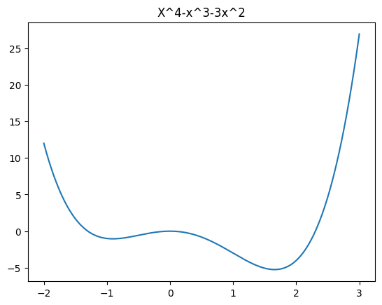

```python
#graph of f.
x = np.arange(-2,3,0.001)
f = x**4 - x**3 - 3*x**2
plt.plot(x,f)
plt.title("X^4-x^3-3x^2")
```

Finding gradient: d/dx (fx) = 4x^3 - 3x^2 - 6x Using 100 iteration and step size of 0.1

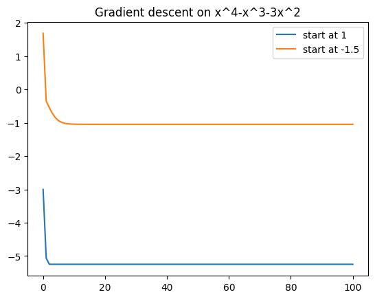

```python
#gradient descent
x, trajectory = gd.gd(lambda x: x**4 - x**3 - 3*x**2, lambda x: 4*x**3-3*x**2-6*x, 1, 100, 0.1)
plt.plot(trajectory, label = "start at 1")
x2, trajectory2 = gd.gd(lambda x: x**4 - x**3 - 3*x**2, lambda x: 4*x**3-3*x**2-6*x, -1.5, 100, 0.1)
plt.plot(trajectory2, label = "start at -1.5")
plt.legend()
plt.title("Gradient descent on x^4-x^3-3x^2")
plt.show()
```

```python
#printing out x as result of gd.
print(x)
print(x2)
```

```
1.6558688457449502
-0.9058688084239377
```

We see that when starting at 1, gd was able to find global minimum But when we started at -1.5, gd got stuck in local minimum

## **WU5**

For each of the loss functions, train a model on the binary version of the wine data (called WineDataBinary) and evaluate it on the test data. You should use lambda=1 in all cases. Which works best? For that best model, look at the learned weights. Find the words corresponding to the weights with the greatest positive value and those with the greatest negative value. Hint: look at WineDataBinary.words to get the id-to-word mapping. List the top 5 positive and top 5 negative and explain.

```python
print("square loss")
sq = linear.LinearClassifier({'lossFunction': linear.SquaredLoss(), 'lambda': 1, 'numIter': 100, 'stepSize': 0.5})
runClassifier.trainTestSet(sq,WineDataBinary)
print("hinge loss")
hinge = linear.LinearClassifier({'lossFunction': linear.HingeLoss(), 'lambda': 1, 'numIter': 100, 'stepSize': 0.5})
runClassifier.trainTestSet(hinge,WineDataBinary)
print("logistic loss")
log = linear.LinearClassifier({'lossFunction': linear.LogisticLoss(), 'lambda': 1, 'numIter': 100, 'stepSize': 0.5})
runClassifier.trainTestSet(log,WineDataBinary)

#retreiving words
words = WineDataBinary.words


#mapping weight to word as list of tuple
result = list(zip(log.getRepresentation(),words))
#sort by weight
result = sorted(result)

print("five most negative words")
neg = result[:5]
print(neg)


print("five most positive result")
pos = result[-5:]
print(pos)
```

```
square loss
Training accuracy 0.242915, test accuracy 0.313653
hinge loss
Training accuracy 0.753036, test accuracy 0.686347
logistic loss
Training accuracy 0.995951, test accuracy 0.97417
five most negative words
[(-1.1695212164040438, '2011'), (-0.7653093906427083, '10'), (-0.6835931677893792, '%'), (-0.6295907281434366, 'as'), (-0.5321916724675304, 'between')]
five most positive result
[(0.6064232619016866, 'approachable'), (0.6891990079029966, 'aromas'), (0.7108905521536923, 'both'), (0.7701247691557759, 'boysenberry'), (0.8832897531176551, 'gives')]
```

Thus, getting the learned weigts from logistic loss model, mapping to the words from WineDataBinary, we have Top five most positive:

1. 'gives' with weight 0.8832897531176551
2. 'boysenberry' with weight 0.7701247691557759
3. 'both' with weight 0.7108905521536923
4. 'aromas' with weight 0.6891990079029966
5. 'approachable' with weight 0.6064232619016866

Top 5 most negative:  
the positive words are mostly words that contribute to most to predicting positive class.

1. '2011' with weight -1.1695212164040438
2. '10' with weight -0.7653093906427083
3. '%' with weight -0.6835931677893792
4. 'as' with weight -0.6295907281434366
5. 'between' with weight -0.5321916724675304

negative are the words that contribute most to predicting negative class.